# HW3 BAX400-01

Analyze the following parts and then based on your analysis write the interpretations and recommendations.

1. Yˇouhˇao is concerned that one or more of the new delivery people might be slower than others.
1. Let μDi and μTi be the mean delivery time and mean total time for delivery person i, where the total time is the sum of the delivery and prep times. Calculate and interpret 95% confidence intervals for each of these means for each delivery person. Although these might be interesting, give two reasons why they are not really fair measures for comparing the efficiency of the delivery people.
2. Responding to the criticisms in part (i), calculate and interpret a 95% confidence interval for the mean speed of delivery for each delivery person, where speed is measured as miles per hour during the trip from Yˇouhˇao to the customer. Then calculate and interpret 95% confidence intervals for the mean difference in speed between each pair of delivery people. Assume equal variances between the groups.
2. Yˇouhˇao would like to advertise that it can achieve a total delivery time of no more than M minutes for all customers within a 10-mile radius. On all orders that take more than M minutes, Yˇouhˇao will give the customers a $10 certificate on their next purchase.
1. Assuming for now that the delivery people in the sample are represen- tative of all of Yˇouhˇao’s delivery people, calculate and interpret a 95% confidence interval for the proportion of deliveries (within the 10-mile limit) that will be on time if M = 25 minutes; if M = 30 minutes; if M = 35 minutes.
2. Suppose Yˇouhˇao makes 1000 deliveries within the 10-mile limit. For each of the values of M in part (i), calculate the range for the dollar amount of certificates it will have to pay for being late.
3. The policy in the previous part is simple to state and simple to administer. However, it is somewhat unfair to customers who live close to Yˇouhˇao — they will never get $10 certificates. A fairer policy is the following. Yˇouhˇao first analyzes the data and finds that total delivery times can be predicted fairly well with the regression equation Predicted Delivery Time = 14.8 + 2.06Distance

Also, most of these predictions are within 5 minutes of the actual delivery times. Therefore, whenever Yˇouhˇao receives an order over the phone, it looks up the customer’s address in its computerized geographical database to find distance, calculates the predicted delivery time based on this equation, rounds this to the nearest minute, adds 5 minutes, and guarantees this delivery time or else a $10 certificate. It does this for all customers, even those beyond the 10-mile limit.

1. Assuming again that the delivery people in the sample are representa- tive of all of Yˇouhaˇo’s delivery people, calculate and interpret a 95% confidence interval for the proportion of all deliveries that will be within the guaranteed total delivery time.
2. Suppose Yˇouhˇao makes 1000 deliveries. Calculate the range for the dollar amount of certificates it will have to pay for being late.

```r
#Read data
df <- read.csv("DeliveryTimes.csv")
#Add a column of total time
df$Total.Time <- df$Prep.Time+df$Travel.Time
#Part a
#Find the sample sizes for each deliverer
n_1 <- sum(df$Deliverer=="1")
n_2 <- sum(df$Deliverer=="2")
n_3 <- sum(df$Deliverer=="3")
n_4 <- sum(df$Deliverer=="4")
#Find the mean and standard deviation of travel time for each deliverer
xbar_d_1 <- mean(df[df$Deliverer =="1",]$Travel.Time)
xbar_d_2 <- mean(df[df$Deliverer =="2",]$Travel.Time)
xbar_d_3 <- mean(df[df$Deliverer =="3",]$Travel.Time)
xbar_d_4 <- mean(df[df$Deliverer =="4",]$Travel.Time)
s_d_1 <- sd(df[df$Deliverer =="1",]$Travel.Time)
s_d_2 <- sd(df[df$Deliverer =="2",]$Travel.Time)
s_d_3 <- sd(df[df$Deliverer =="3",]$Travel.Time)
s_d_4 <- sd(df[df$Deliverer =="4",]$Travel.Time)
#Find the mean and standard deviation of total time for each deliverer
xbar_t_1 <- mean(df[df$Deliverer =="1",]$Total.Time)
xbar_t_2 <- mean(df[df$Deliverer =="2",]$Total.Time)
xbar_t_3 <- mean(df[df$Deliverer =="3",]$Total.Time)
xbar_t_4 <- mean(df[df$Deliverer =="4",]$Total.Time)
s_t_1 <- sd(df[df$Deliverer =="1",]$Total.Time)
s_t_2 <- sd(df[df$Deliverer =="2",]$Total.Time)
s_t_3 <- sd(df[df$Deliverer =="3",]$Total.Time)
s_t_4 <- sd(df[df$Deliverer =="4",]$Total.Time)
#Find each confidence interval
sprintf("The 95%% confidence interval of travel time and total time for each deliveres are shown below, units are in minutes.")
```

```
## [1] "The 95% confidence interval of travel time and total time for each deliveres are shown below, units are in minutes."
```

```r
interval_95_mean(xbar_d_1,n_1,s_d_1)
```

```
## [1] "95 percent Confidence Interval: (9.34, 15.16). INTERPRETATION: We might be 95 percent confident that the interval between 9.34 and 15.16 contains the true mean."
```

```r
interval_95_mean(xbar_d_2,n_2,s_d_2)
```

```
## [1] "95 percent Confidence Interval: (10.47, 19). INTERPRETATION: We might be 95 percent confident that the interval between 10.47 and 19 contains the true mean."
```

```r
interval_95_mean(xbar_d_3,n_3,s_d_3)
```

```
## [1] "95 percent Confidence Interval: (15.49, 23.94). INTERPRETATION: We might be 95 percent confident that the interval between 15.49 and 23.94 contains the true mean."
```

```r
interval_95_mean(xbar_d_4,n_4,s_d_4)
```

```
## [1] "95 percent Confidence Interval: (15.26, 25.23). INTERPRETATION: We might be 95 percent confident that the interval between 15.26 and 25.23 contains the true mean."
```

```r
interval_95_mean(xbar_t_1,n_1,s_t_1)
```

```
## [1] "95 percent Confidence Interval: (20.56, 26.49). INTERPRETATION: We might be 95 percent confident that the interval between 20.56 and 26.49 contains the true mean."
```

```r
interval_95_mean(xbar_t_2,n_2,s_t_2)
```

```
## [1] "95 percent Confidence Interval: (22.18, 30.89). INTERPRETATION: We might be 95 percent confident that the interval between 22.18 and 30.89 contains the true mean."
```

```r
interval_95_mean(xbar_t_3,n_3,s_t_3)
```

```
## [1] "95 percent Confidence Interval: (26.52, 35.05). INTERPRETATION: We might be 95 percent confident that the interval between 26.52 and 35.05 contains the true mean."
```

```r
interval_95_mean(xbar_t_4,n_4,s_t_4)
```

```
## [1] "95 percent Confidence Interval: (26.62, 37.96). INTERPRETATION: We might be 95 percent confident that the interval between 26.62 and 37.96 contains the true mean."
```

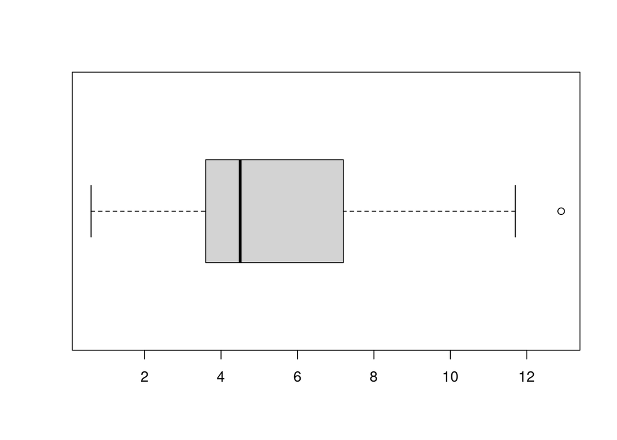

```r
#Check statistics for each deliverers distance and analyze
m1 <- mean(df[df$Deliverer=="1",]$Distance)
boxplot(df[df$Deliverer=="1",]$Distance, horizontal = TRUE)
```

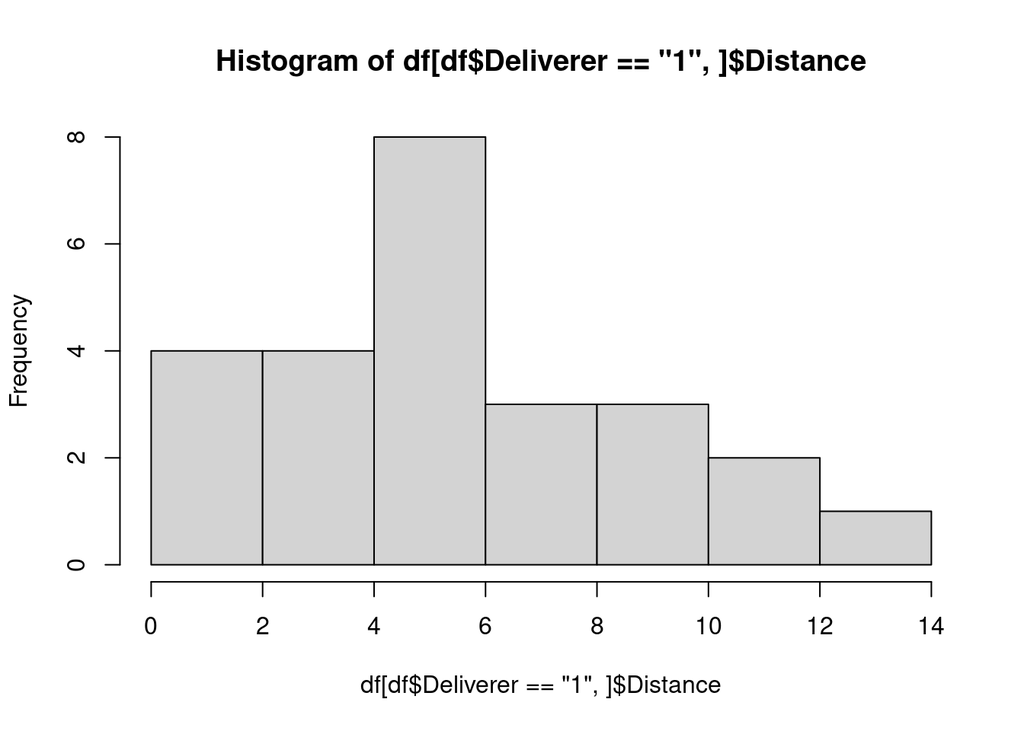

```r
hist(df[df$Deliverer=="1",]$Distance)
```

```r
fivenum(df[df$Deliverer=="1",]$Distance)
```

```
## [1]  0.6  3.6  4.5  7.2 12.9
```

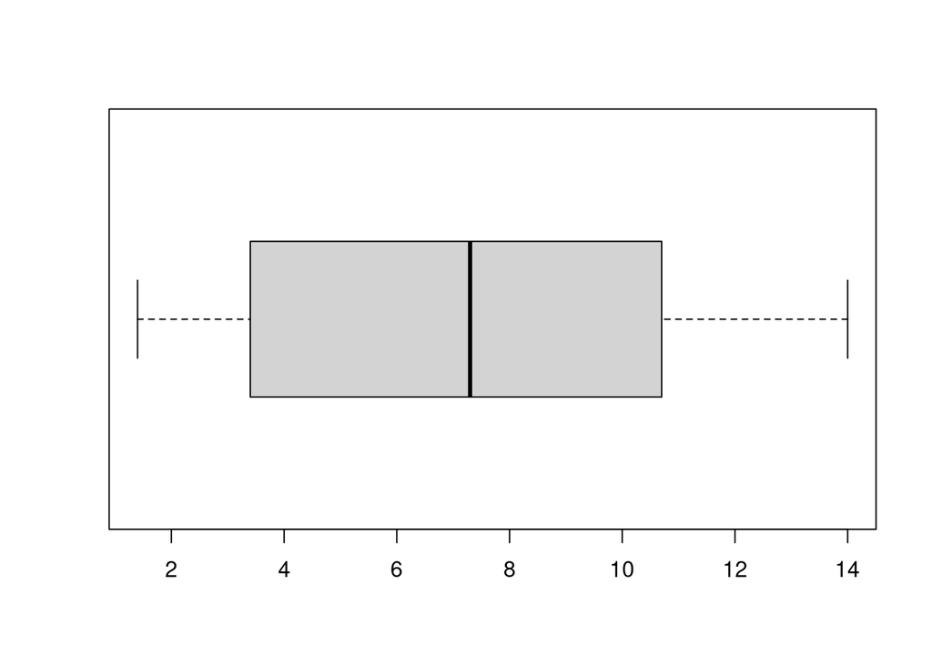

```r
m2 <- mean(df[df$Deliverer=="2",]$Distance)
boxplot(df[df$Deliverer=="2",]$Distance, horizontal = TRUE)
```

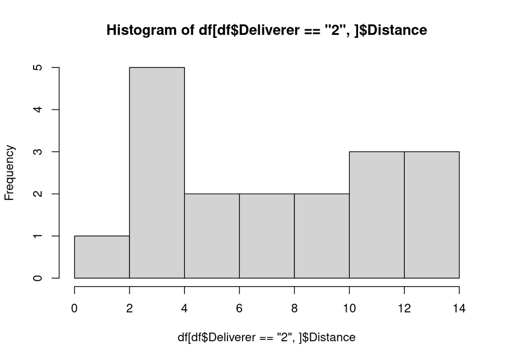

```r
hist(df[df$Deliverer=="2",]$Distance)
```

```r
fivenum(df[df$Deliverer=="2",]$Distance)
```

```
## [1]  1.4  3.4  7.3 10.7 14.0
```

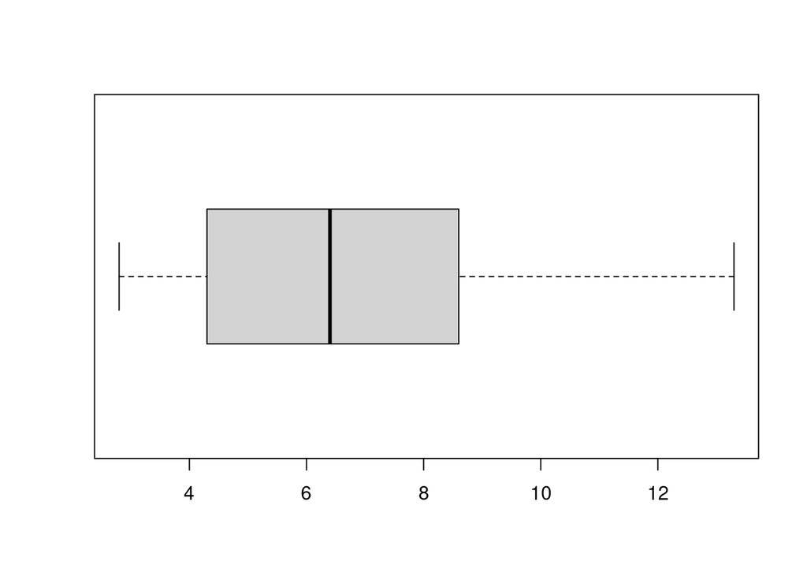

```r
m3 <- mean(df[df$Deliverer=="3",]$Distance)
boxplot(df[df$Deliverer=="3",]$Distance, horizontal = TRUE)
```

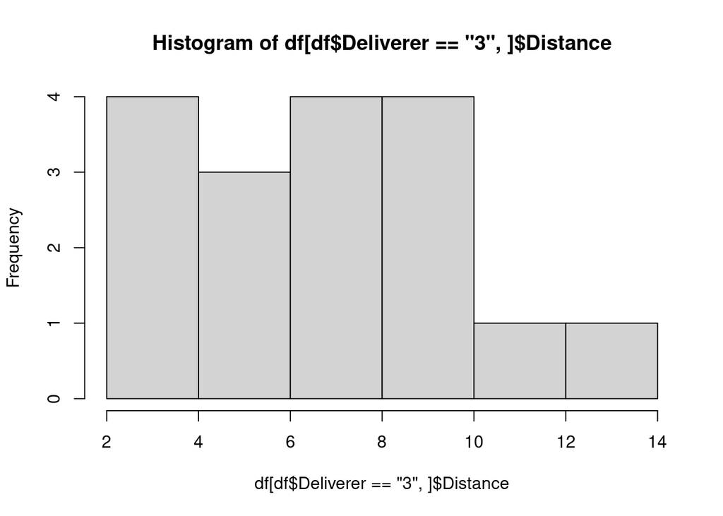

```r
hist(df[df$Deliverer=="3",]$Distance)
```

```r
fivenum(df[df$Deliverer=="3",]$Distance)
```

```
## [1]  2.8  4.3  6.4  8.6 13.3
```

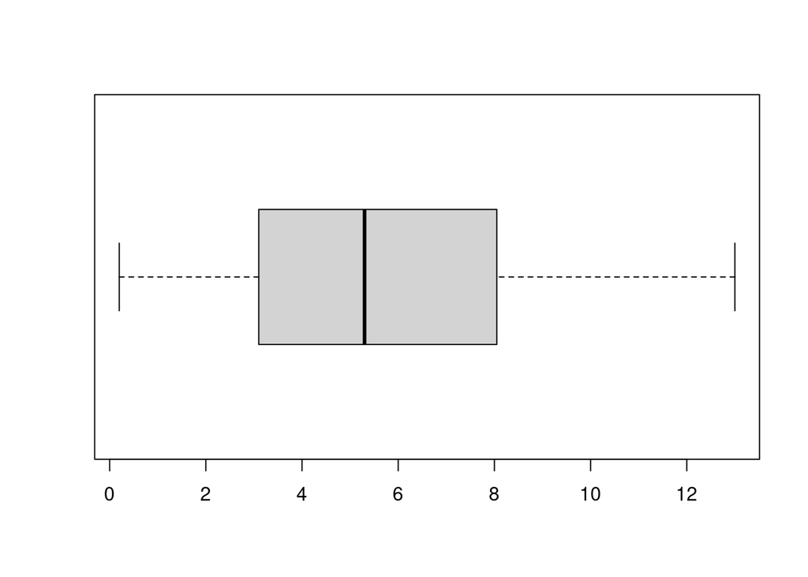

```r
m4 <- mean(df[df$Deliverer=="4",]$Distance)
boxplot(df[df$Deliverer=="4",]$Distance, horizontal = TRUE)
```

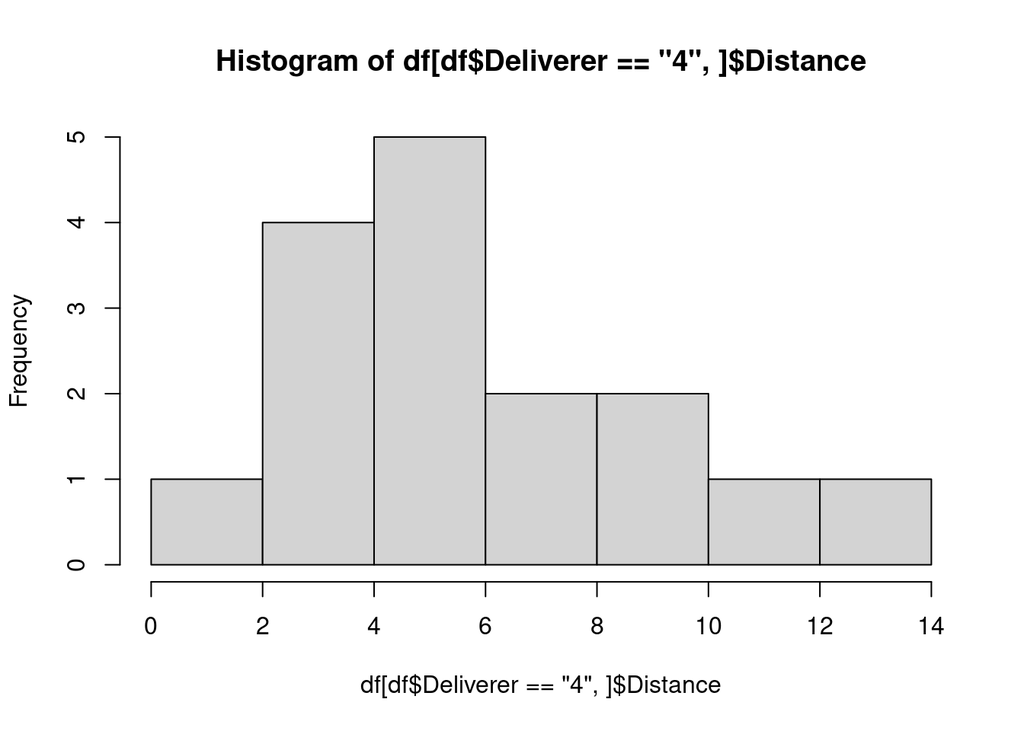

```r
hist(df[df$Deliverer=="4",]$Distance)
```

```r
fivenum(df[df$Deliverer=="4",]$Distance)
```

```
## [1]  0.20  3.10  5.30  8.05 13.00
```

```r
sprintf("Although interesting, the intervals above do not really have any significance because it only considers time, after you look at the distribution of the distances of each order, you can see that there is variation between deliverers, so a better way to analyze the data is to take both distance and time into consideration, which is suggested by the following question.")
```

```
## [1] "Although interesting, the intervals above do not really have any significance because it only considers time, after you look at the distribution of the distances of each order, you can see that there is variation between deliverers, so a better way to analyze the data is to take both distanc…
```

```r
#Calculate speed of each order
df$speed <- df$Distance/(df$Travel.Time/60)
#Run t.test for each pair
test12 <- t.test(df[df$Deliverer=="1",]$speed, df[df$Deliverer=="2",]$speed, var.equal = TRUE, paired = FALSE, conf.level = 0.95)
test13 <- t.test(df[df$Deliverer=="1",]$speed, df[df$Deliverer=="3",]$speed, var.equal = TRUE, paired = FALSE, conf.level = 0.95)
test14 <- t.test(df[df$Deliverer=="1",]$speed, df[df$Deliverer=="4",]$speed, var.equal = TRUE, paired = FALSE, conf.level = 0.95)
test23 <- t.test(df[df$Deliverer=="2",]$speed, df[df$Deliverer=="3",]$speed, var.equal = TRUE, paired = FALSE, conf.level = 0.95)
test24 <- t.test(df[df$Deliverer=="2",]$speed, df[df$Deliverer=="4",]$speed, var.equal = TRUE, paired = FALSE, conf.level = 0.95)
test34 <- t.test(df[df$Deliverer=="3",]$speed, df[df$Deliverer=="4",]$speed, var.equal = TRUE, paired = FALSE, conf.level = 0.95)
#Print out the intervals for each differences and interpret
sprintf("The 95%% confidence interval of difference between delivery speed for each pair of deliveres are shown below, units are miles per hour.")
```

```
## [1] "The 95% confidence interval of difference between delivery speed for each pair of deliveres are shown below, units are miles per hour."
```

```r
sprintf("95 percent Confidence Interval of difference between delivery speed of deliverer 1 & 2: (%.2f, %.2f) (miles per hour). INTERPRETATION: We might be 95 percent confident that the interval between %.2f(miles per hour) and %.2f(miles per hour) contains the true difference.",test12$conf.int[1],test12$conf.int[2], test12$conf.int[1], test12$conf.int[2])
```

```
## [1] "95 percent Confidence Interval of difference between delivery speed of deliverer 1 & 2: (-6.38, -0.68) (miles per hour). INTERPRETATION: We might be 95 percent confident that the interval between -6.38(miles per hour) and -0.68(miles per hour) contains the true difference."
```

```r
sprintf("95 percent Confidence Interval of difference between delivery speed of deliverer 1 & 3: (%.2f, %.2f) (miles per hour). INTERPRETATION: We might be 95 percent confident that the interval between %.2f(miles per hour) and %.2f(miles per hour) contains the true difference.",test13$conf.int[1],test13$conf.int[2], test13$conf.int[1], test13$conf.int[2])
```

```
## [1] "95 percent Confidence Interval of difference between delivery speed of deliverer 1 & 3: (2.92, 8.48) (miles per hour). INTERPRETATION: We might be 95 percent confident that the interval between 2.92(miles per hour) and 8.48(miles per hour) contains the true difference."
```

```r
sprintf("95 percent Confidence Interval of difference between delivery speed of deliverer 1 & 4: (%.2f, %.2f) (miles per hour). INTERPRETATION: We might be 95 percent confident that the interval between %.2f(miles per hour) and %.2f(miles per hour) contains the true difference.",test14$conf.int[1],test14$conf.int[2], test14$conf.int[1], test14$conf.int[2])
```

```
## [1] "95 percent Confidence Interval of difference between delivery speed of deliverer 1 & 4: (5.67, 12.22) (miles per hour). INTERPRETATION: We might be 95 percent confident that the interval between 5.67(miles per hour) and 12.22(miles per hour) contains the true difference."
```

```r
sprintf("95 percent Confidence Interval of difference between delivery speed of deliverer 2 & 3: (%.2f, %.2f) (miles per hour). INTERPRETATION: We might be 95 percent confident that the interval between %.2f(miles per hour) and %.2f(miles per hour) contains the true difference.",test23$conf.int[1],test23$conf.int[2], test23$conf.int[1], test23$conf.int[2])
```

```
## [1] "95 percent Confidence Interval of difference between delivery speed of deliverer 2 & 3: (6.18, 12.28) (miles per hour). INTERPRETATION: We might be 95 percent confident that the interval between 6.18(miles per hour) and 12.28(miles per hour) contains the true difference."
```

```r
sprintf("95 percent Confidence Interval of difference between delivery speed of deliverer 2 & 4: (%.2f, %.2f) (miles per hour). INTERPRETATION: We might be 95 percent confident that the interval between %.2f(miles per hour) and %.2f(miles per hour) contains the true difference.",test24$conf.int[1],test24$conf.int[2], test24$conf.int[1], test24$conf.int[2])
```

```
## [1] "95 percent Confidence Interval of difference between delivery speed of deliverer 2 & 4: (8.81, 16.14) (miles per hour). INTERPRETATION: We might be 95 percent confident that the interval between 8.81(miles per hour) and 16.14(miles per hour) contains the true difference."
```

```r
sprintf("95 percent Confidence Interval of difference between delivery speed of deliverer 3 & 4: (%.2f, %.2f) (miles per hour). INTERPRETATION: We might be 95 percent confident that the interval between %.2f(miles per hour) and %.2f(miles per hour) contains the true difference.",test34$conf.int[1],test34$conf.int[2], test34$conf.int[1], test34$conf.int[2])
```

```
## [1] "95 percent Confidence Interval of difference between delivery speed of deliverer 3 & 4: (-0.34, 6.83) (miles per hour). INTERPRETATION: We might be 95 percent confident that the interval between -0.34(miles per hour) and 6.83(miles per hour) contains the true difference."
```

```r
#Part b
#Find the delivery orders that have a radius whitin 10 miles
df_10_miles <- df[df$Distance<=10,]
#Set the the M values
M1 = 25
M2 = 30
M3 = 35
#Get samplesize
samplesize <- length(df_10_miles$Order)
#Count proportions under each M
p_25_10 <- sum(df_10_miles$Total.Time <= M1)/samplesize
p_30_10 <- sum(df_10_miles$Total.Time <= M2)/samplesize
p_35_10 <- sum(df_10_miles$Total.Time <= M3)/samplesize
#Print the intervals and interpret
sprintf("The 95%% confidence interval of the proportion of orders within 10 miles radius that will be complete within the given 25, 30, 35 (minutes) limit are shown below.")
```

```
## [1] "The 95% confidence interval of the proportion of orders within 10 miles radius that will be complete within the given 25, 30, 35 (minutes) limit are shown below."
```

```r
interval_95(p_25_10,samplesize)
```

```
## [1] "95 percent Confidence Interval: (0.4492, 0.6936). INTERPRETATION: We might be 95 percent confident that the interval between 0.4492 and 0.6936 proportion contains the true population proportion."
```

```r
interval_95(p_30_10,samplesize)
```

```
## [1] "95 percent Confidence Interval: (0.6027, 0.8258). INTERPRETATION: We might be 95 percent confident that the interval between 0.6027 and 0.8258 proportion contains the true population proportion."
```

```r
interval_95(p_35_10,samplesize)
```

```
## [1] "95 percent Confidence Interval: (0.751, 0.9315). INTERPRETATION: We might be 95 percent confident that the interval between 0.751 and 0.9315 proportion contains the true population proportion."
```

```r
#Find the proportion of failure and find the intervals
sprintf("The 95%% confidence interval of the proportion of orders within 10 miles radius that will NOT be complete within the given 25, 30, 35 (minutes) limit are shown below.")
```

```
## [1] "The 95% confidence interval of the proportion of orders within 10 miles radius that will NOT be complete within the given 25, 30, 35 (minutes) limit are shown below."
```

```r
interval_95((1-p_25_10),samplesize)
```

```
## [1] "95 percent Confidence Interval: (0.3064, 0.5508). INTERPRETATION: We might be 95 percent confident that the interval between 0.3064 and 0.5508 proportion contains the true population proportion."
```

```r
interval_95((1-p_30_10),samplesize)
```

```
## [1] "95 percent Confidence Interval: (0.1742, 0.3973). INTERPRETATION: We might be 95 percent confident that the interval between 0.1742 and 0.3973 proportion contains the true population proportion."
```

```r
interval_95((1-p_35_10),samplesize)
```

```
## [1] "95 percent Confidence Interval: (0.0685, 0.249). INTERPRETATION: We might be 95 percent confident that the interval between 0.0685 and 0.249 proportion contains the true population proportion."
```

```r
#Calculate the range for the dollar amount of certificates it will have to pay for being late
sprintf("The range for the dollar amount of certificates the restaurant will have to pay under 95%% confidence level when M is 25 minutes is:($%.f,$%.f)",0.3064*1000*10,0.5508*1000*10)
```

```
## [1] "The range for the dollar amount of certificates the restaurant will have to pay under 95% confidence level when M is 25 minutes is:($3064,$5508)"
```

```r
sprintf("The range for the dollar amount of certificates the restaurant will have to pay under 95%% confidence level when M is 30 minutes is:($%.f,$%.f)",0.1742*1000*10,0.3973*1000*10)
```

```
## [1] "The range for the dollar amount of certificates the restaurant will have to pay under 95% confidence level when M is 30 minutes is:($1742,$3973)"
```

```r
sprintf("The range for the dollar amount of certificates the restaurant will have to pay under 95%% confidence level when M is 35 minutes is:($%.f,$%.f)",0.0685*1000*10,0.249*1000*10)
```

```
## [1] "The range for the dollar amount of certificates the restaurant will have to pay under 95% confidence level when M is 35 minutes is:($685,$2490)"
```

```r
#Part c
#Use the formula given to compute the guaranteed delivery time
df$Guaranteed.Time <- round(df$Distance*2.06+14.8)+5
df$Witihin.Guaranteed <- ifelse(df$Total.Time<=df$Guaranteed.Time, 1, 0)
n <- length(df$Order)
p_within <- sum(df$Witihin.Guaranteed==1)/n
sprintf("The 95%% confidence interval of the proportion of orders that will be completed within the guaranteed time(minutes) limit are shown below.")
```

```
## [1] "The 95% confidence interval of the proportion of orders that will be completed within the guaranteed time(minutes) limit are shown below."
```

```r
interval_95(p_within,n)
```

```
## [1] "95 percent Confidence Interval: (0.7443, 0.9136). INTERPRETATION: We might be 95 percent confident that the interval between 0.7443 and 0.9136 proportion contains the true population proportion."
```

```r
sprintf("The 95%% confidence interval of the proportion of orders that will NOT be completed within the guaranteed time(minutes) limit are shown below.")
```

```
## [1] "The 95% confidence interval of the proportion of orders that will NOT be completed within the guaranteed time(minutes) limit are shown below."
```

```r
interval_95((1-p_within),n)
```

```
## [1] "95 percent Confidence Interval: (0.0864, 0.2557). INTERPRETATION: We might be 95 percent confident that the interval between 0.0864 and 0.2557 proportion contains the true population proportion."
```

```r
sprintf("The range for the dollar amount of certificates the restaurant will have to pay under 95%% confidence level based on each orders guaranteed time is:($%.f,$%.f)",0.0864*1000*10,0.2557*1000*10)
```

```
## [1] "The range for the dollar amount of certificates the restaurant will have to pay under 95% confidence level based on each orders guaranteed time is:($864,$2557)"
```

Question 6

A large courier company sends invoices to customers requesting payment within 30 days. Each bill lists an address, and customers are expected to use their own envelopes to return their payments. Currently, the mean amount of time taken to pay bills are 24 days. The chief financial officer (CFO) believes that including a stamped self-addressed (SSA) envelope would decrease the amount of time. She calculates that the improved cash flow from a 2-day decrease in the payment period would pay for the costs of the envelopes and stamps. Any further decrease in the payment period would generate a profit. To test her belief, she randomly selects 220 customers and includes an SSA envelope with their invoices. The numbers of days until payment is received were recorded on the CSV file SSA. Can the CFO conclude that the plan will be profitable? Make a decision using an appropriate level of significance. Choose a significance level by performing the Type I and Type II error analysis. Also please state your null and alternative hypotheses.
$$H_0:\mu\ge22days\\H_1:\mu <22days$$

```r
#Type I error would lead to losses from costs from implementing the new plan
#Type II error would lead to loss of potential gains
#Read data
df <- read.csv("SSA.csv")
#Get sample size, mean, hypothesis and standard deviation
n <- length(df$Payment)
hyp <- 22
mu <- 24
s <- sd(df$Payment)
#Create a list of alphas
alphas <- c(0.01,0.05,0.1)
#Run power t test and t test for each alphas
for (i in alphas){
  t <- pwr.t.test(n = n,d = (mu-hyp)/s,sig.level = i ,power = NULL, type = "one.sample",alternative = "less")
  print(t)
}
```

```
##
##      One-sample t test power calculation
##
##               n = 220
##               d = 0.34274
##       sig.level = 0.01
##           power = 2.521316e-13
##     alternative = less
##
##
##      One-sample t test power calculation
##
##               n = 220
##               d = 0.34274
##       sig.level = 0.05
##           power = 9.592549e-12
##     alternative = less
##
##
##      One-sample t test power calculation
##
##               n = 220
##               d = 0.34274
##       sig.level = 0.1
##           power = 1.037388e-10
##     alternative = less
```

```r
for (i in alphas){
t <- t.test(df$Payment, alternative = "less", mu = hyp, conf.level = 1-i)
print(t)
}
```

```
##
##  One Sample t-test
##
## data:  df$Payment
## t = -0.93585, df = 219, p-value = 0.1752
## alternative hypothesis: true mean is less than 22
## 99 percent confidence interval:
##      -Inf 22.55379
## sample estimates:
## mean of x
##  21.63182
##
##
##  One Sample t-test
##
## data:  df$Payment
## t = -0.93585, df = 219, p-value = 0.1752
## alternative hypothesis: true mean is less than 22
## 95 percent confidence interval:
##      -Inf 22.28168
## sample estimates:
## mean of x
##  21.63182
##
##
##  One Sample t-test
##
## data:  df$Payment
## t = -0.93585, df = 219, p-value = 0.1752
## alternative hypothesis: true mean is less than 22
## 90 percent confidence interval:
##      -Inf 22.13753
## sample estimates:
## mean of x
##  21.63182
```

```r
sprintf("Comparing two types of error: Type I means losses from costs of implementing the new plan when it is not profitable, Type II error means loss on potential gains. Type I error should be more severe to the business as it has risk of actual losses. Hence we should try to avoid Type I error by choosing a smaller alpha. We choose alpha as 0.01")
```

```
## [1] "Comparing two types of error: Type I means losses from costs of implementing the new plan when it is not profitable, Type II error means loss on potential gains. Type I error should be more severe to the business as it has risk of actual losses. Hence we should try to avoid Type I error by c…
```

```r
sprintf("After analysis, we can conclude that at 1%% significance level, there is not sufficient evidence to support the claim that the new plan would be profitable. And comparing p-value to alpha, we fail to reject the Null hypothesis, hence my decision would be NOT to implement the new plan to include SSA envelopes.")
```

```
## [1] "After analysis, we can conclude that at 1% significance level, there is not sufficient evidence to support the claim that the new plan would be profitable. And comparing p-value to alpha, we fail to reject the Null hypothesis, hence my decision would be NOT to implement the new plan to inclu…
```

Question 7

When an election for political office takes place, the television networks cancel regular programming and instead provide election coverage. When the ballots are counted, the results are reported. However, for important offices such as president or senator in large states, the networks actively compete to see which will be the first to predict a winner. This is done through exit polls, wherein a random sample of voters who exit the polling booth is asked for whom they voted. From the data, the sample proportion of voters supporting the candidates is computed. A statistical technique is applied to determine whether there is enough evidence to infer that the leading candidate will garner enough votes to win. Suppose that in the exit poll from the state of Florida during the 2000 year elections, the pollsters recorded only the votes of the two candidates who had any chance of winning, Democrat Albert Gore (code = 1) and Republican George W. Bush (code = 2). The polls close at 8:00 p.m. Can the networks conclude from these data that the Republican candidate will win the state? Should the network announce at 8:01 p.m. that the Republican candidate will win? Use a 10% significance level. Also please state your null and alternative hypotheses. Write your final interpretation. The dataset is available on the CSV file Elections.

$$H_0:\widehat{p}\le0.5\\H_1:\widehat{p}
>0.5$$

```r
#Read data, use significance level 0.1 to analyze
df <- read.csv("Elections.csv")
#Count republican votes
num_rep <- sum(df$Votes =="2")
#Run prop.test
prop_t <- prop.test(num_rep,length(df$Votes),alternative = "greater", p=0.5)
print(prop_t)
```

```
##
##  1-sample proportions test with continuity correction
##
## data:  num_rep out of length(df$Votes), null probability 0.5
## X-squared = 3.0118, df = 1, p-value = 0.04133
## alternative hypothesis: true p is greater than 0.5
## 95 percent confidence interval:
##  0.5016378 1.0000000
## sample estimates:
##         p
## 0.5320261
```

```r
#Print interpretation
sprintf("The prop.test gives us the p-value = 0.04133, which is smaller than our alpha 0.1, we can conclude and make a decision to reject the Null hypothesis, and to claim that the Republican candidate will win the state of Florida. The network should announce at 8:01p.m. that the Republican candidate will win.")
```

```
## [1] "The prop.test gives us the p-value = 0.04133, which is smaller than our alpha 0.1, we can conclude and make a decision to reject the Null hypothesis, and to claim that the Republican candidate will win the state of Florida. The network should announce at 8:01p.m. that the Republican candidat…
```

Question 8

A study is performed in a large town to determine whether the average amount spent on food per four-person family in the town is significantly different from the national average. A random sample of the weekly grocery bills of four-person families in this town is given in the file GroceryBills. Assume the national average amount spent on food for a four-person family is $150.

1. Identify the null and alternative hypotheses for this situation. Is the sample evidence statistically significant? If so, at what significance levels can you reject the null hypothesis?
2. For which values of the test statistic, sample mean (i.e., average weekly grocery bill), would you reject the null hypothesis at the 1% significance level? For which values of the test statistic, sample mean, would you reject the null hypothesis at the 10% level?